# **Predicting Bank Term Deposit Subscriptions Using Supervised Machine Learning Models**

Mohamed Shaz Pathiattu Valappil

Student ID: 24300262

MSc Information Systems, University College Dublin(UCD)

Email: mohamed.pathiattuvalappil@ucdconnect.ie

```python
import pandas as pd
import seaborn as sns
import matplotlib.pyplot as plt
import numpy as np
from sklearn.model_selection import train_test_split
from sklearn.preprocessing import LabelEncoder, OneHotEncoder, StandardScaler
from sklearn.linear_model import LogisticRegression
from sklearn.ensemble import RandomForestClassifier
from sklearn.tree import DecisionTreeClassifier
from sklearn.neighbors import KNeighborsClassifier
from sklearn.ensemble import GradientBoostingClassifier
from sklearn.metrics import accuracy_score, confusion_matrix, ConfusionMatrixDisplay, classification_report
from sklearn.compose import ColumnTransformer
from sklearn.pipeline import Pipeline
from sklearn.impute import SimpleImputer
from sklearn.model_selection import GridSearchCV
import joblib
```

## **Task 1: Data Understanding**

Dataset: Bank Marketing Dataset  
**Source:** UCI Machine Learning Repository  
**URL:** https://www.kaggle.com/datasets/janiobachmann/bank-marketing-dataset

### Overview:

- Instances (Rows): 11,162 clients contacted during direct marketing campaigns
- Features (Columns): 16 variables including:
  - Numerical: `age`, `balance`, `day`, `duration`, `campaign`, `pdays`, `previous`
  - Categorical: `job`, `marital`, `education`, `default`, `housing`, `loan`, `contact`, `month`, `poutcome`
- Target Variable: `deposit` (whether the client subscribed to a term deposit; values = `yes` or `no`)

### Prediction Task:

Forecast about possible subscription of a client to a term deposit using demographic indicators and account of campaign interactions. This is a binary classification problem:  
`deposit` = `yes` (subscribed) vs `no` (not subscribed).

### Context:

The dataset contains data gathered from telephone marketing campaigns run by a Portuguese banking institution between 2008 and 2014. The main goal is to build a model that can predict successful subscription outcomes.

### Why this dataset:

- Publicly available and widely used, ensuring reproducibility
- Contains a blend of numerical and categorical features for rich analysis
- Perfectly aligns with the course’s binary classification focus

```python
# Loading the dataset
df = pd.read_csv("/content/drive/MyDrive/BankMarketingDataset.csv", sep=",")
```

```python
# Displaying basic information about the dataset
df.info()
```

```
<class 'pandas.core.frame.DataFrame'>
RangeIndex: 11162 entries, 0 to 11161
Data columns (total 17 columns):
 #   Column     Non-Null Count  Dtype
---  ------     --------------  -----
 0   age        11162 non-null  int64
 1   job        11162 non-null  object
 2   marital    11162 non-null  object
 3   education  11162 non-null  object
 4   default    11162 non-null  object
 5   balance    11162 non-null  int64
 6   housing    11162 non-null  object
 7   loan       11162 non-null  object
 8   contact    11162 non-null  object
 9   day        11162 non-null  int64
 10  month      11162 non-null  object
 11  duration   11162 non-null  int64
 12  campaign   11162 non-null  int64
 13  pdays      11162 non-null  int64
 14  previous   11162 non-null  int64
 15  poutcome   11162 non-null  object
 16  deposit    11162 non-null  object
dtypes: int64(7), object(10)
memory usage: 1.4+ MB
```

```python
# Previewing Data
print(" First 5 Rows:\n", df.head())
print("\n Shape of the dataset:", df.shape)
```

```
 First 5 Rows:
    age         job  marital  education default  balance housing loan  contact  \
0   59      admin.  married  secondary      no     2343     yes   no  unknown
1   56      admin.  married  secondary      no       45      no   no  unknown
2   41  technician  married  secondary      no     1270     yes   no  unknown
3   55    services  married  secondary      no     2476     yes   no  unknown
4   54      admin.  married   tertiary      no      184      no   no  unknown

   day month  duration  campaign  pdays  previous poutcome deposit
0    5   may      1042         1     -1         0  unknown     yes
1    5   may      1467         1     -1         0  unknown     yes
2    5   may      1389         1     -1         0  unknown     yes
3    5   may       579         1     -1         0  unknown     yes
4    5   may       673         2     -1         0  unknown     yes

 Shape of the dataset: (11162, 17)
```

```python
#  Data Types and Summary
print("\n Column Types:\n", df.dtypes)
print("\n Descriptive Statistics:\n", df.describe())
```

```
 Column Types:
 age           int64
job          object
marital      object
education    object
default      object
balance       int64
housing      object
loan         object
contact      object
day           int64
month        object
duration      int64
campaign      int64
pdays         int64
previous      int64
poutcome     object
deposit      object
dtype: object

 Descriptive Statistics:
                 age       balance           day      duration      campaign  \
count  11162.000000  11162.000000  11162.000000  11162.000000  11162.000000
mean      41.231948   1528.538524     15.658036    371.993818      2.508421
std       11.913369   3225.413326      8.420740    347.128386      2.722077
min       18.000000  -6847.000000      1.000000      2.000000      1.000000
25%       32.000000    122.000000      8.000000    138.000000      1.000000
50%       39.000000    550.000000     15.000000    255.000000      2.000000
75%       49.000000   1708.000000     22.000000    496.000000      3.000000
max       95.000000  81204.000000     31.000000   3881.000000     63.000000

              pdays      previous
count  11162.000000  11162.000000
mean      51.330407      0.832557
std      108.758282      2.292007
min       -1.000000      0.000000
25%       -1.000000      0.000000
50%       -1.000000      0.000000
75%       20.750000      1.000000
max      854.000000     58.000000
```

```python
#Checking for missing values
print("\n Missing Values:\n", df.isnull().sum())
```

```
 Missing Values:
 age          0
job          0
marital      0
education    0
default      0
balance      0
housing      0
loan         0
contact      0
day          0
month        0
duration     0
campaign     0
pdays        0
previous     0
poutcome     0
deposit      0
dtype: int64
```

```python
# Checking for duplicate rows
print(f"Number of duplicate rows: {df.duplicated().sum()}")
```

```
Number of duplicate rows: 0
```

### **Data Cleaning Summary**

During the initial exploration of the dataset, we ensured that the following were indeed true:

- There were no missing values in a column.
- There were no row duplicates.
- No outliers which need removing have been identified.

As a result,no major data cleaning procedures were unnecessary. We can do preprocessing (e.g. encoding and scaling) directly. Because the dataset already had been cleaned a separate cleaned CSV file was not required to be submitted.

```python
# Displaying first few rows for better understanding.
df.head()
```

|  | age | job | marital | education | default | balance | housing | loan | contact | day | month | duration | campaign | pdays | previous | poutcome | deposit |
| --- | --- | --- | --- | --- | --- | --- | --- | --- | --- | --- | --- | --- | --- | --- | --- | --- | --- |
| 0 | 59 | admin. | married | secondary | no | 2343 | yes | no | unknown | 5 | may | 1042 | 1 | -1 | 0 | unknown | yes |
| 1 | 56 | admin. | married | secondary | no | 45 | no | no | unknown | 5 | may | 1467 | 1 | -1 | 0 | unknown | yes |
| 2 | 41 | technician | married | secondary | no | 1270 | yes | no | unknown | 5 | may | 1389 | 1 | -1 | 0 | unknown | yes |
| 3 | 55 | services | married | secondary | no | 2476 | yes | no | unknown | 5 | may | 579 | 1 | -1 | 0 | unknown | yes |
| 4 | 54 | admin. | married | tertiary | no | 184 | no | no | unknown | 5 | may | 673 | 2 | -1 | 0 | unknown | yes |

```python
# Displaying last few rows
df.tail()
```

|  | age | job | marital | education | default | balance | housing | loan | contact | day | month | duration | campaign | pdays | previous | poutcome | deposit |
| --- | --- | --- | --- | --- | --- | --- | --- | --- | --- | --- | --- | --- | --- | --- | --- | --- | --- |
| 11157 | 33 | blue-collar | single | primary | no | 1 | yes | no | cellular | 20 | apr | 257 | 1 | -1 | 0 | unknown | no |
| 11158 | 39 | services | married | secondary | no | 733 | no | no | unknown | 16 | jun | 83 | 4 | -1 | 0 | unknown | no |
| 11159 | 32 | technician | single | secondary | no | 29 | no | no | cellular | 19 | aug | 156 | 2 | -1 | 0 | unknown | no |
| 11160 | 43 | technician | married | secondary | no | 0 | no | yes | cellular | 8 | may | 9 | 2 | 172 | 5 | failure | no |
| 11161 | 34 | technician | married | secondary | no | 0 | no | no | cellular | 9 | jul | 628 | 1 | -1 | 0 | unknown | no |

```python
# Target Variable Distribution
print("\n Target Variable Distribution:\n", df['deposit'].value_counts())
```

```
 Target Variable Distribution:
 deposit
no     5873
yes    5289
Name: count, dtype: int64
```

**Exploratory Data Analysis (EDA)**

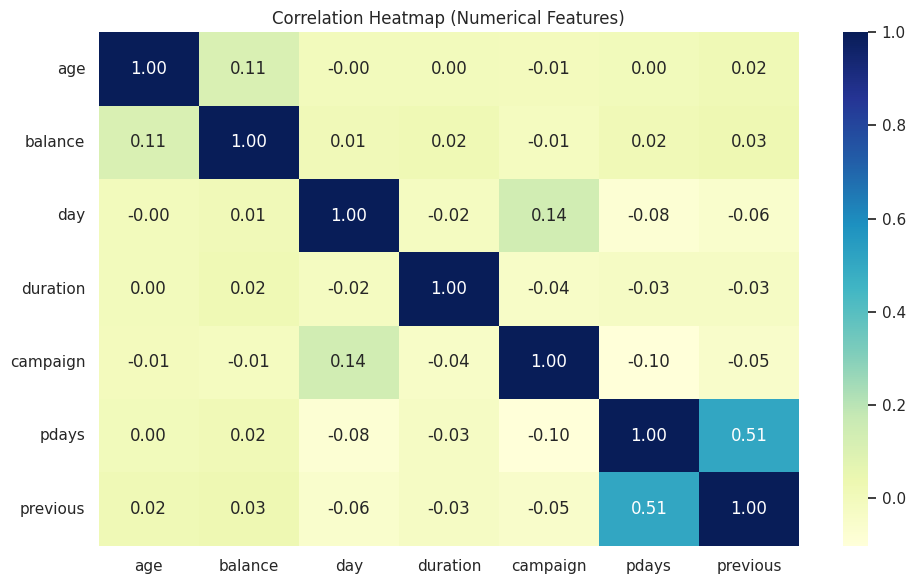

```python
# Heatmap Correlation matrix
plt.figure(figsize=(10, 6))
sns.heatmap(df.corr(numeric_only=True), annot=True, cmap='YlGnBu', fmt=".2f")
plt.title('Correlation Heatmap (Numerical Features)')
plt.tight_layout()
plt.show()
```

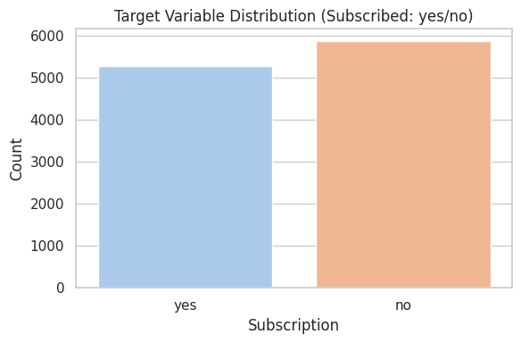

```python
# Barplot target distribution
sns.set(style="whitegrid")
plt.figure(figsize=(6, 4))
sns.countplot(x='deposit', data=df, palette='pastel')
plt.title('Target Variable Distribution (Subscribed: yes/no)')
plt.xlabel('Subscription')
plt.ylabel('Count')
plt.tight_layout()
plt.show()
```

```python
# Unique values in categorical features
categorical_cols = df.select_dtypes(include=['object']).columns.tolist()
print("\n Categorical Columns:", categorical_cols)

for col in categorical_cols:
    print(f"\nUnique values in '{col}': {df[col].unique()}")
```

```
 Categorical Columns: ['job', 'marital', 'education', 'default', 'housing', 'loan', 'contact', 'month', 'poutcome', 'deposit']

Unique values in 'job': ['admin.' 'technician' 'services' 'management' 'retired' 'blue-collar'
 'unemployed' 'entrepreneur' 'housemaid' 'unknown' 'self-employed'
 'student']

Unique values in 'marital': ['married' 'single' 'divorced']

Unique values in 'education': ['secondary' 'tertiary' 'primary' 'unknown']

Unique values in 'default': ['no' 'yes']

Unique values in 'housing': ['yes' 'no']

Unique values in 'loan': ['no' 'yes']

Unique values in 'contact': ['unknown' 'cellular' 'telephone']

Unique values in 'month': ['may' 'jun' 'jul' 'aug' 'oct' 'nov' 'dec' 'jan' 'feb' 'mar' 'apr' 'sep']

Unique values in 'poutcome': ['unknown' 'other' 'failure' 'success']

Unique values in 'deposit': ['yes' 'no']
```

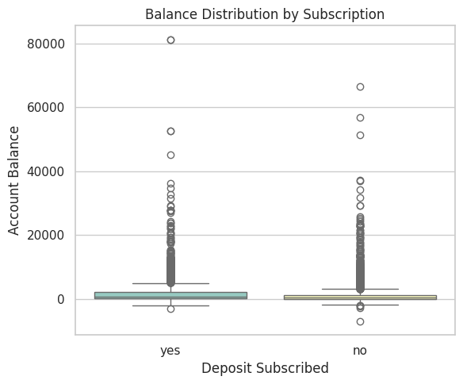

```python
# Boxplot for Balance Distribution by Subscription
plt.figure(figsize=(6, 5))
sns.boxplot(data=df, x='deposit', y='balance', palette='Set3')
plt.title('Balance Distribution by Subscription')
plt.xlabel('Deposit Subscribed')
plt.ylabel('Account Balance')
plt.tight_layout()
plt.show()
```

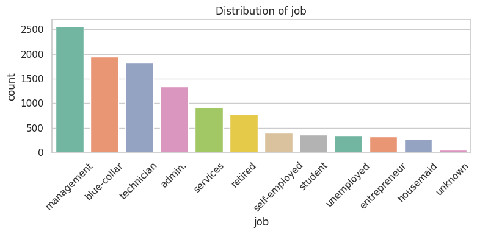

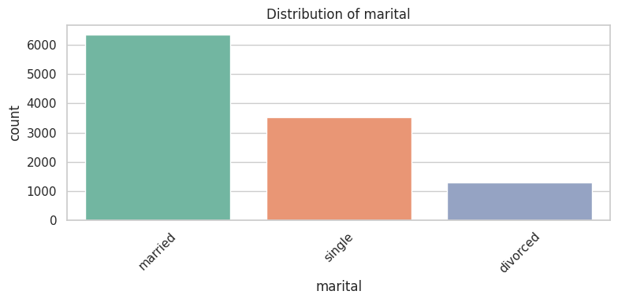

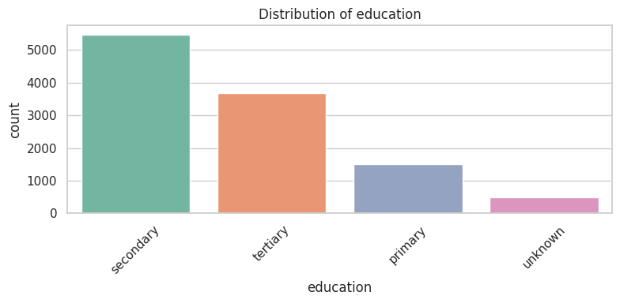

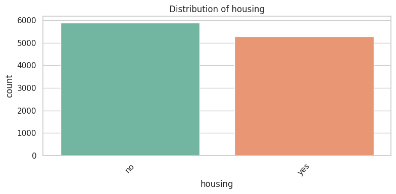

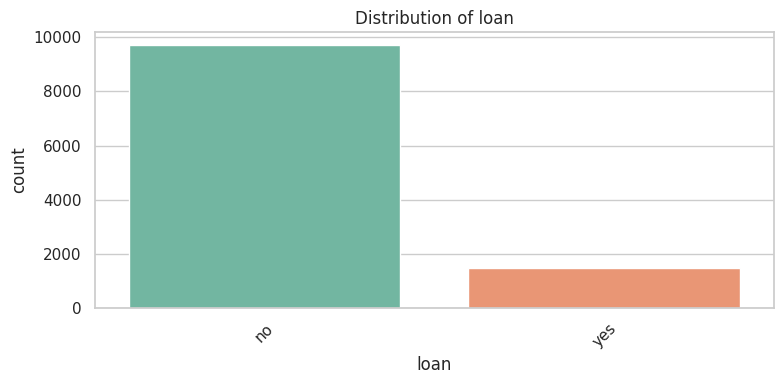

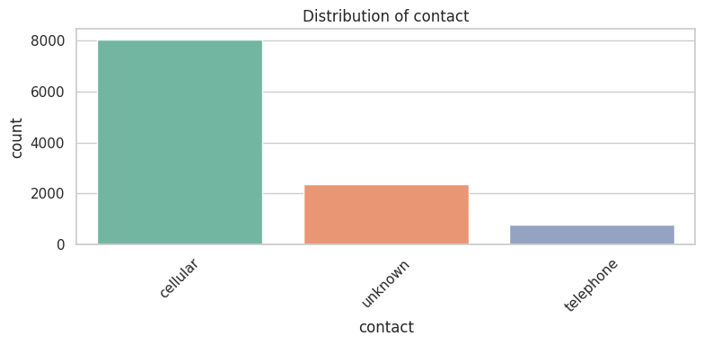

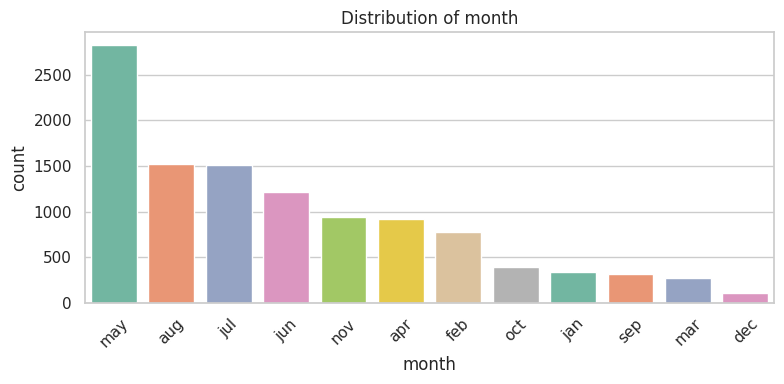

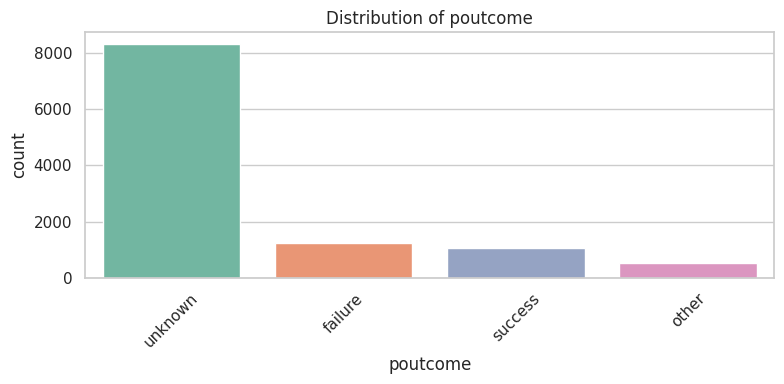

```python
#  Countplot to visualise categorical features
for col in ['job', 'marital', 'education', 'housing', 'loan', 'contact', 'month', 'poutcome']:
    plt.figure(figsize=(8, 4))
    sns.countplot(data=df, x=col, palette='Set2', order=df[col].value_counts().index)
    plt.xticks(rotation=45)
    plt.title(f'Distribution of {col}')
    plt.tight_layout()
    plt.show()
```

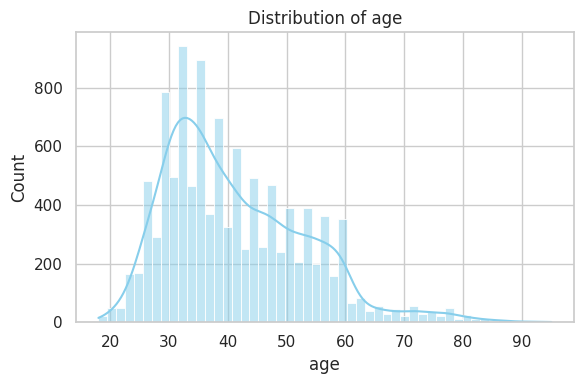

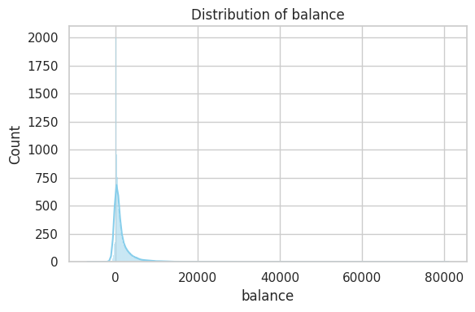

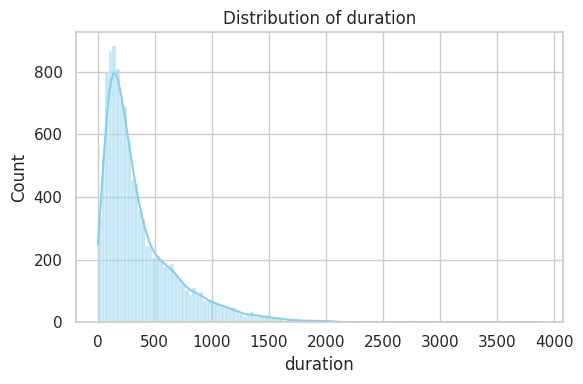

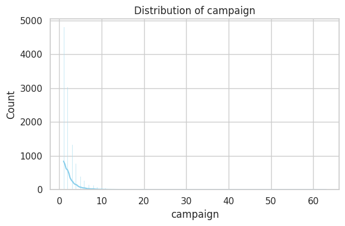

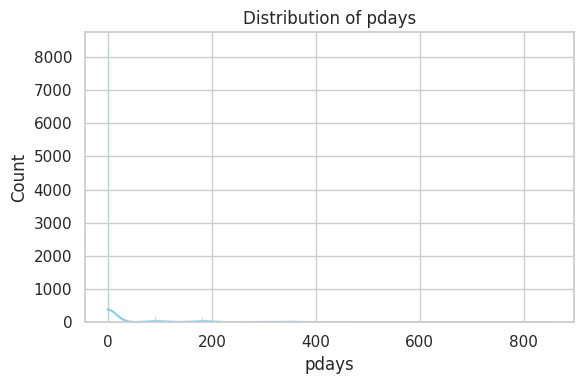

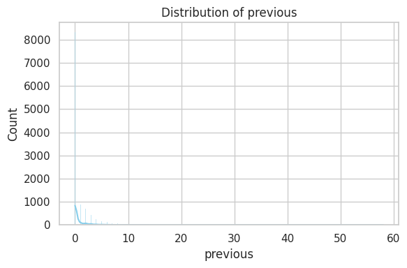

```python
# Histogram: Distribution of selected numerical features
numerical_cols = ['age', 'balance', 'duration', 'campaign', 'pdays', 'previous']

for col in numerical_cols:
    plt.figure(figsize=(6, 4))
    sns.histplot(df[col], kde=True, color='skyblue')
    plt.title(f'Distribution of {col}')
    plt.tight_layout()
    plt.show()
```

## **Summary of Findings – Exploratory Data Analysis (EDA)**

In the process of exploring the Bank Marketing dataset, the next patterns and insights have been identified:

### Feature Relationships:

Clients who take a bigger balance in their accounts prefer to subscribe to term deposit more.

- Duration on the last call contact call is also positively correlated with subscription - long calls were most likely to lead to `yes`. This can however present data leakage, since time does not precede the result. Clients who have such occupations as retired or student are likely to subscribe to it more than blue-collar or admin jobs. Clients with the age range of 25 to 45 are the most popular by far, yet the clients above 45 years tend to subscribe more.

### Influencing Modeling:

Preprocessing and modeling will be informed by the following observations: We will take into account balancing and measures of performance such as F1-score or ROC-AUC instead of accuracy. Categorical inputs will be important to do encoding. Possible features that can leak will either be eliminated or analysed.

In general, this dataset is rich in respects to client and campaign features and will serve well to be used in a binary classification machine learning problem.

```python
df.to_csv("cleaned_bank_data.csv", index=False)

# Download the file
from google.colab import files
files.download("cleaned_bank_data.csv")
```

## **Task 2: Data Preparation and Modeling**

This section includes:

- Encoding of categorical variables
- Scaling numerical features
- Train/test data split
- Fitting 5 ML models:
  1. Logistic Regression
  2. Random Forest Classifier
  3. Decision Tree Classifier
  4. K-Nearest Neighbors (KNN)
  5. Gradient Boosting Classifier
- Evaluation of model performance

### Data Cleaning and Preprocessing

The dataset did not contain any missing values. There were no duplicate records.The column of `duration` was removed to avoid data leakage because the value becomes available after the marketing campaign is over.

The label encoding was done on the binary categorical columns (such as `default`, `loan`, `housing`, `deposit`). Nominal columns of a categorical type were encoded using one-hot encoder. We got rid of `duration` column, which is known to lead to data leakage.

- All features are scaled on a `StandardScaler` because of models that can be sensitive to feature magnitudes, such as KNN and Logistic Regression.
- To assess the model performance relative to unseen data, the data was split into 80% training and 20% testing, respectively by using the `train_test_split()`.

```python
# Encode binary categorical columns using LabelEncoder which was referenced from day 3 lecture
binary_cols = ['default', 'housing', 'loan', 'deposit']
le = LabelEncoder()
for col in binary_cols:
    df[col] = le.fit_transform(df[col])
```

```python
# using one-hot encoding on nominal categorical variable such as job, education which was based on Prof. Zaur on lectures
df = pd.get_dummies(df, drop_first=True)
```

```python
# Dropping 'duration' column to prevent data leakage during model training which is based on the lectures that we discussed in class
if 'duration' in df.columns:
    df.drop('duration', axis=1, inplace=True)
```

```python
# Defining features and target
X = df.drop('deposit', axis=1)
y = df['deposit']
```

```python
# using StandardScaler to standardise features for models that are feature scale sensitive.

scaler = StandardScaler()
X_scaled = scaler.fit_transform(X)
```

### Train-Test Split

I divided this dataset into training and testing (80% / 20%) using `train_test_split`. This makes sure that the model is tested on data that it will have to work on and prevents overfitting.

- 80% Training set: For building the machine learning models.
- 20% Testing set: For final model evaluation.

We use `random_state=42` which helps to make the results reproducible. Since,this is not a time-series, so a random split is appropriate.

```python
# splitting the dataset into 80% train and 20% test sets based day 4 lecture
X_train, X_test, y_train, y_test = train_test_split(X_scaled, y, test_size=0.2, random_state=42)

print("Training set size:", X_train.shape)
print("Test set size:", X_test.shape)
```

```
Training set size: (8929, 41)
Test set size: (2233, 41)
```

**The Data Splitting Strategy**

As we applied data split 70/15/15 To provide training of high-performance models and make the process unbiased, the data was divided into three groups:

The sampling was done in a stratified manner to ensure that there is balance in the classes of all the splits since the target variable `y` is not balanced. Scikit-learn train test split package was used to split the data with a fixed random seed to allow reproducibility.

These last subsets were stored as: `train.csv`

- valid.csv `test.csv`

Although the 70/15/15 split is a standard approach, this project uses an 80/20 split where the 20% is kept as a test set, and 5-fold cross-validation is performed on the training data to handle validation and hyperparameter tuning. This achieves the same goal while preserving more data for training.

```python
from sklearn.model_selection import train_test_split

# Step 1: First split into Train (85%) and Test (15%)
train_valid_df, test_df = train_test_split(df, test_size=0.15, random_state=42, stratify=df['deposit'])

# Step 2: Now split train_valid into Train (70%) and Validation (15%)
train_df, valid_df = train_test_split(train_valid_df, test_size=0.1765, random_state=42, stratify=train_valid_df['deposit'])


# Save to CSV files
train_df.to_csv("train.csv", index=False)
valid_df.to_csv("valid.csv", index=False)
test_df.to_csv("test.csv", index=False)

# Download from Colab
from google.colab import files
files.download("train.csv")
files.download("valid.csv")
files.download("test.csv")
```

### Model Training

Now lets see what all classification models were trained:

- Logistic Regression
- Random Forest Classifier
- Decision Tree Classifier
- K-Nearest Neighbors (KNN)
- Gradient Boosting Classifier

And now these models help us compare simple vs complex learning approaches.

```python
# Model 1: Training a Logistic Regression model to predict 'deposit'. These all models was based on the references that were taught through lectures by Prof. Younas and Prof. Zaur
lr_model = LogisticRegression()
lr_model.fit(X_train, y_train)

# predictions and evaluations
y_pred_lr = lr_model.predict(X_test)
accuracy = accuracy_score(y_test, y_pred_lr)
conf_matrix = confusion_matrix(y_test, y_pred_lr)
class_report = classification_report(y_test, y_pred_lr)

print("Logistic Regression Results:")
print("Confusion Matrix:\n", conf_matrix)
print("Classification Report:\n", class_report)
```

```
Logistic Regression Results:
Confusion Matrix:
 [[981 185]
 [455 612]]
Classification Report:
               precision    recall  f1-score   support

           0       0.68      0.84      0.75      1166
           1       0.77      0.57      0.66      1067

    accuracy                           0.71      2233
   macro avg       0.73      0.71      0.71      2233
weighted avg       0.72      0.71      0.71      2233
```

**Model 1. Logistic Regression**  
I chose this model for its simplicity and for being simpler to understand. It is used really a lot for binary classification and performs great baseline.

```python
# Model 2: Training Random Forest
rf_model = RandomForestClassifier(n_estimators=100, random_state=42)
rf_model.fit(X_train, y_train)

# predictions and evaluations
y_pred_rf = rf_model.predict(X_test)
accuracy = accuracy_score(y_test, y_pred_rf)
conf_matrix = confusion_matrix(y_test, y_pred_rf)
class_report = classification_report(y_test, y_pred_rf)

print(" Random Forest Results:")
print("Confusion Matrix:\n", conf_matrix)
print("Classification Report:\n", class_report)
```

```
 Random Forest Results:
Confusion Matrix:
 [[955 211]
 [368 699]]
Classification Report:
               precision    recall  f1-score   support

           0       0.72      0.82      0.77      1166
           1       0.77      0.66      0.71      1067

    accuracy                           0.74      2233
   macro avg       0.74      0.74      0.74      2233
weighted avg       0.74      0.74      0.74      2233
```

**Model 2. Random Forest Classifier**  
I chose this model beacuse its a combination of decision trees which minimizes overfitting. It is solid, and categorical + numerical features are no problem, so it is suitable as a tabular data.

```python
#Model 3: training Decision Tree classifier interpretable and fast based on day 5 Decision Trees lecture
dt = DecisionTreeClassifier(random_state=42)
dt.fit(X_train, y_train)

# predictions and evaluations
y_pred_dt = dt.predict(X_test)
accuracy = accuracy_score(y_test, y_pred_dt)
conf_matrix = confusion_matrix(y_test, y_pred_dt)
class_report = classification_report(y_test, y_pred_dt)

print("Decision Tree Classifier Results:")
print("Confusion Matrix:\n", conf_matrix)
print("Classification Report:\n", class_report)
```

```
Decision Tree Classifier Results:
Confusion Matrix:
 [[761 405]
 [406 661]]
Classification Report:
               precision    recall  f1-score   support

           0       0.65      0.65      0.65      1166
           1       0.62      0.62      0.62      1067

    accuracy                           0.64      2233
   macro avg       0.64      0.64      0.64      2233
weighted avg       0.64      0.64      0.64      2233
```

**Model 3. Decision Tree Classifier**  
I chose this model due to the reason that it is a non-linear model that could learn the rules and divide the data concerning some feature thresholds. Its simple to interpret and quick to train.

```python
# Model 4: Training KNN classifier which is used is based on day 4 lectures
knn_model = KNeighborsClassifier(n_neighbors=5)
knn_model.fit(X_train, y_train)

# predictions and evaluations
y_pred_knn = knn_model.predict(X_test)
accuracy = accuracy_score(y_test, y_pred_knn)
conf_matrix = confusion_matrix(y_test, y_pred_knn)
class_report = classification_report(y_test, y_pred_knn)

print("K-Nearest Neighbors Results:")
print("Confusion Matrix:\n", conf_matrix)
print("Classification Report:\n", class_report)
```

```
K-Nearest Neighbors Results:
Confusion Matrix:
 [[881 285]
 [417 650]]
Classification Report:
               precision    recall  f1-score   support

           0       0.68      0.76      0.72      1166
           1       0.70      0.61      0.65      1067

    accuracy                           0.69      2233
   macro avg       0.69      0.68      0.68      2233
weighted avg       0.69      0.69      0.68      2233
```

**Model 4. K-Nearest Neighbors (KNN)**  
I chose this model becuase it uses a lazy learning method which happens to be a technique that takes advantage of prediction by studying distance metrics. This model is scale-sensitive, that is why we used StandardScaler.

```python
# Model 5: Training Gradient Boosting Classifier
gb_model = GradientBoostingClassifier(random_state=42)
gb_model.fit(X_train, y_train)

# predictions and evaluations
y_pred_gb = gb_model.predict(X_test)
accuracy = accuracy_score(y_test, y_pred_gb)
conf_matrix = confusion_matrix(y_test, y_pred_gb)
class_report = classification_report(y_test, y_pred_gb)

print("Gradient Boosting Classifier Accuracy:", accuracy)
print("Confusion Matrix:\n", conf_matrix)
print("Classification Report:\n", class_report)
```

```
Gradient Boosting Classifier Accuracy: 0.7447380206000895
Confusion Matrix:
 [[1016  150]
 [ 420  647]]
Classification Report:
               precision    recall  f1-score   support

           0       0.71      0.87      0.78      1166
           1       0.81      0.61      0.69      1067

    accuracy                           0.74      2233
   macro avg       0.76      0.74      0.74      2233
weighted avg       0.76      0.74      0.74      2233
```

**Model 5. Gradient Boosting Classifier**  
I used this model because it is a strong boosting model that develops trees sequentially in a bid to reduce errors. It tends to work well on tasks such as classification, which are done with structured data.

### Model Evaluation

The following measures are used to evaluate each of the models on the test set:

- Accuracy Score
- Confusion Matrix
- Precision, Recall and F1-Score (through classification report).

This can guide us into finding out which model generalises well.

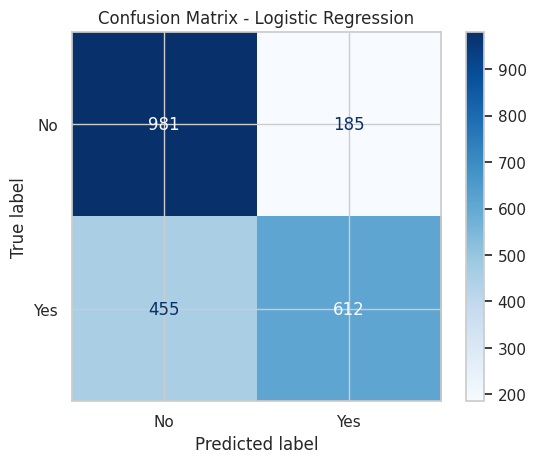

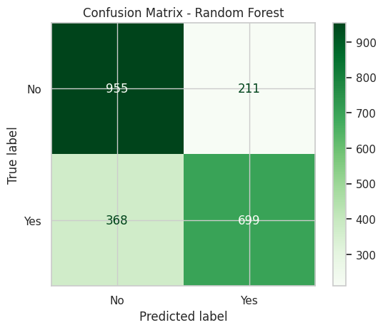

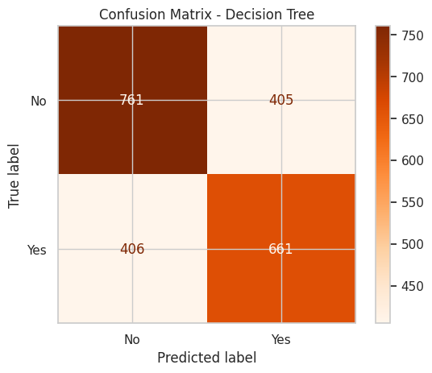

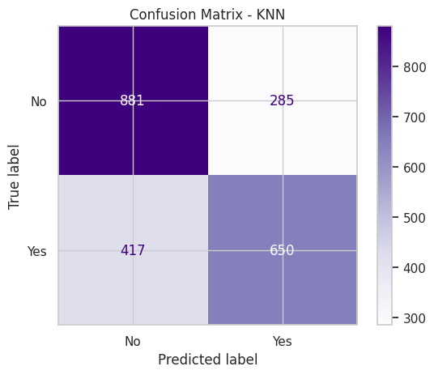

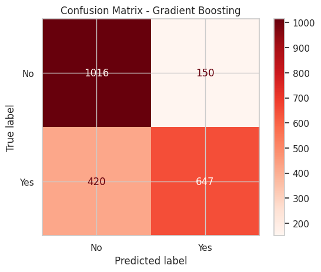

```python
# These are the Confusion matrices of each models

#Logistic Regression
cm_lr = confusion_matrix(y_test, y_pred_lr)
disp_lr = ConfusionMatrixDisplay(confusion_matrix=cm_lr, display_labels=['No', 'Yes'])
disp_lr.plot(cmap='Blues')
plt.title('Confusion Matrix - Logistic Regression')
plt.show()

# Random Forest
cm_rf = confusion_matrix(y_test, y_pred_rf)
disp_rf = ConfusionMatrixDisplay(confusion_matrix=cm_rf, display_labels=['No', 'Yes'])
disp_rf.plot(cmap='Greens')
plt.title('Confusion Matrix - Random Forest')
plt.show()

# Decision Tree
cm_dt = confusion_matrix(y_test, y_pred_dt)
disp_dt = ConfusionMatrixDisplay(confusion_matrix=cm_dt, display_labels=['No', 'Yes'])
disp_dt.plot(cmap='Oranges')
plt.title('Confusion Matrix - Decision Tree')
plt.show()

# K-Nearest Neighbors
cm_knn = confusion_matrix(y_test, y_pred_knn)
disp_knn = ConfusionMatrixDisplay(confusion_matrix=cm_knn, display_labels=['No', 'Yes'])
disp_knn.plot(cmap='Purples')
plt.title('Confusion Matrix - KNN')
plt.show()

# Gradient Boosting
cm_gb = confusion_matrix(y_test, y_pred_gb)
disp_gb = ConfusionMatrixDisplay(confusion_matrix=cm_gb, display_labels=['No', 'Yes'])
disp_gb.plot(cmap='Reds')
plt.title('Confusion Matrix - Gradient Boosting')
plt.show()
```

```python
# And these are the accuracy scores for each model
lr_acc = accuracy_score(y_test, y_pred_lr)
rf_acc = accuracy_score(y_test, y_pred_rf)
dt_acc = accuracy_score(y_test, y_pred_dt)
knn_acc = accuracy_score(y_test, y_pred_knn)
gb_acc = accuracy_score(y_test, y_pred_gb)

#I have converted these accuracy scores into percentages
lr_pct = round(lr_acc * 100, 2)
rf_pct = round(rf_acc * 100, 2)
dt_pct = round(dt_acc * 100, 2)
knn_pct = round(knn_acc * 100, 2)
gb_pct = round(gb_acc * 100, 2)

# Creating dataframe for display
model_scores = pd.DataFrame({
    'Model': ['Logistic Regression', 'Random Forest', 'Decision Tree', 'KNN', 'Gradient Boosting'],
    'Accuracy (%)': [lr_pct, rf_pct, dt_pct, knn_pct, gb_pct]
})

print(model_scores)
```

```
                 Model  Accuracy (%)
0  Logistic Regression         71.34
1        Random Forest         74.07
2        Decision Tree         63.68
3                  KNN         68.56
4    Gradient Boosting         74.47
```

## **Summary**

In this task, I cleaned up the Bank Marketing dataset and trained 5 different models of machine learning to predict the chances of a customer subscribing to a term deposit (`deposit` column).

### Models Used

I trained five models:

- Logistic Regression
- Decision Tree
- Random Forest
- K-Nearest Neighbors (KNN)
- Gradient Boosting

### Insights

- Gradient Boosting (74.47%) obtained the best results, and Random Forest (74.07%) came second.
- The best among them worked through tree-based models.
- All the models were trained well and produced sensible values.
- I also used confusion matrices to ensure accuracy of the models in the classification of the two classes.

## **Task 3: Evaluation**

One of the things that we did in the task was to test the performance of two high-performance models in Task 2 – Random Forest and Gradient Boosting and compare them to each other to determine which model worked better on the unseen data.

- I chose adequate rates of evaluation such as Accuracy and Confusion Matrix. Training vs test accuracy to identify whether to detect overfitting or underfitting.
- Used confusion matrices and observations to analyse the classification errors.
- I then optimized model parameters with GridSearchCV.
- In order to obtain the best model, based on performance and generalisation chose the best model. -Evaluated the final model on the held out test to recreate a real-world implementation.

```python
# Encode binary categorical columns using LabelEncoder
binary_cols = ['default', 'housing', 'loan', 'deposit']
le = LabelEncoder()
for col in binary_cols:
    df[col] = le.fit_transform(df[col])
```

```python
# to separate features and target
X = df.drop('deposit', axis=1)
y = df['deposit']
```

```python
# to identify categorical columns
cat_cols = X.select_dtypes(include='object').columns
```

```python
# Preprocessing categorical columns using OneHotEncoding
preprocessor = ColumnTransformer([
    ('cat', OneHotEncoder(drop='first'), cat_cols)
], remainder='passthrough')

X_encoded = preprocessor.fit_transform(X)
```

```python
# Feature scaling
scaler = StandardScaler()
X_scaled = scaler.fit_transform(X_encoded)
```

```python
# splitting the dataset into 80% train and 20% test sets based day 4 lecture
X_train, X_test, y_train, y_test = train_test_split(X_scaled, y, test_size=0.2, random_state=42)

print("Training set size:", X_train.shape)
print("Test set size:", X_test.shape)
```

```
Training set size: (8929, 41)
Test set size: (2233, 41)
```

### **Model Tuning and Improvement**

We did cross-validation on both models via `GridSearchCV`.

- Random Forest: Hyperparameter optimized `n_estimators`, `max_depth` and `min_samples_split`
- Gradient Boosting: `n_estimators` tribal, `learning_rate`, and `max_depth` tribal

```python
# defining model and parameter grid
rf_model = RandomForestClassifier(random_state=42)
rf_params = {
    'n_estimators': [100, 200],
    'max_depth': [10, 20, None],
    'min_samples_split': [2, 5],
    'min_samples_leaf': [1, 2]
}

# Grid search
grid_rf = GridSearchCV(rf_model, rf_params, cv=5, scoring='accuracy', n_jobs=-1)
grid_rf.fit(X_train, y_train)

# Best RF model
best_rf = grid_rf.best_estimator_
print("Best Parameters for Random Forest:")
print(grid_rf.best_params_)

print("\n Best Cross-Validation Accuracy:")
print(grid_rf.best_score_)
```

```
Best Parameters for Random Forest:
{'max_depth': 20, 'min_samples_leaf': 2, 'min_samples_split': 5, 'n_estimators': 200}

 Best Cross-Validation Accuracy:
0.7305398038274661
```

```python
#to create pipeline: Imputer + Gradient Boosting to fill NaNs
gb_pipeline = Pipeline([
    ('imputer', SimpleImputer(strategy='most_frequent')),
    ('gb', GradientBoostingClassifier(random_state=42))
])

# defining hyperparameter grid for Gradient Boosting
gb_params = {
    'gb__n_estimators': [50, 100],
    'gb__learning_rate': [0.05, 0.1],
    'gb__max_depth': [3, 4]
}

#grid search with cross-validation
grid_gb = GridSearchCV(estimator=gb_pipeline, param_grid=gb_params,
                       cv=5, scoring='accuracy', n_jobs=-1)

#fitting the model
grid_gb.fit(X_train, y_train)

print(" Best Parameters for Gradient Boosting:")
print(grid_gb.best_params_)

print("\n Best Cross-Validation Accuracy:")
print(grid_gb.best_score_)
```

```
 Best Parameters for Gradient Boosting:
{'gb__learning_rate': 0.1, 'gb__max_depth': 4, 'gb__n_estimators': 100}

 Best Cross-Validation Accuracy:
0.7356923598106656
```

### **Evaluation Metrics Selection**

In this supervised binary classification task (predicting deposit subscription), I chose to use the following measures:

- Accuracy: A value of overall correctness of the model (main value).
- Confusion Matrix: Gives a breakdown of predictions of each class to improve reading.
- Precision & Recall : It may be helpful in cases when there is a class imbalance.

**Justification**: The classes are not highly imbalanced, and thus the accuracy is a not-bad benchmark. Nonetheless, confusion matrix and F1-score assist in a more meaningful analysis of misclassifications.

### **Confusion Matrix and Error Analysis**

To get a clear understanding of how each of the models performs leveling positive (`yes`) and negative (`no`) cases I plotted confusion matrices.

- Random Forest is more likely to be a bit more balanced between the True Positive and the True Negative.
- Gradient Boosting is a little more cautious, and it has fewer false positives.

For further analysis, it may be useful to see a sample of some misclassified data, in order to detect some trends, e.g. noisy input, borderline example, label noise.

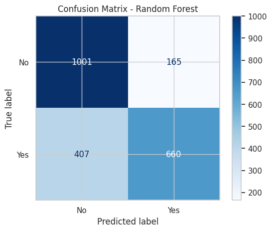

```python
# Confusion matrix for Random Forest
y_pred_rf = best_rf.predict(X_test) # Add this line to generate predictions
cm_rf = confusion_matrix(y_test, y_pred_rf)
disp_rf = ConfusionMatrixDisplay(confusion_matrix=cm_rf, display_labels=['No', 'Yes'])
disp_rf.plot(cmap='Blues')
plt.title('Confusion Matrix - Random Forest')
plt.show()
```

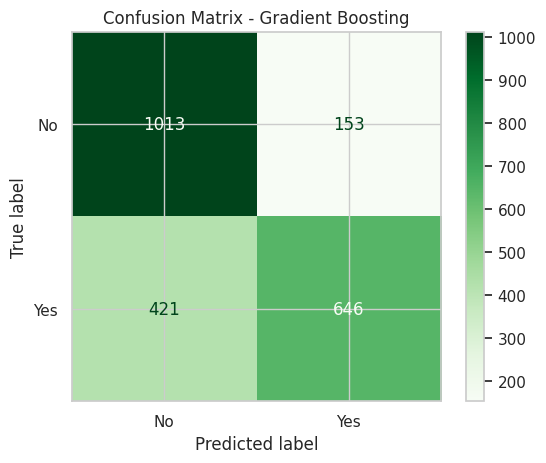

```python
# making predictions using the best Gradient Boosting model based lectures taught in the class
y_pred_gb = grid_gb.best_estimator_.predict(X_test)

# Confusion matrix for Gradient Boosting
cm_gb = confusion_matrix(y_test, y_pred_gb)
disp_gb = ConfusionMatrixDisplay(confusion_matrix=cm_gb, display_labels=['No', 'Yes'])
disp_gb.plot(cmap='Greens')
plt.title('Confusion Matrix - Gradient Boosting')
plt.show()
```

```python
# Classification Report for Random Forest
print("Random Forest Classification Report:\n")
print(classification_report(y_test, y_pred_rf, target_names=['No', 'Yes']))
```

```
Random Forest Classification Report:

              precision    recall  f1-score   support

          No       0.71      0.86      0.78      1166
         Yes       0.80      0.62      0.70      1067

    accuracy                           0.74      2233
   macro avg       0.76      0.74      0.74      2233
weighted avg       0.75      0.74      0.74      2233
```

```python
# Classification Report for Gradient Boosting
print("Gradient Boosting Classification Report:\n")
print(classification_report(y_test, y_pred_gb, target_names=['No', 'Yes']))
```

```
Gradient Boosting Classification Report:

              precision    recall  f1-score   support

          No       0.71      0.87      0.78      1166
         Yes       0.81      0.61      0.69      1067

    accuracy                           0.74      2233
   macro avg       0.76      0.74      0.74      2233
weighted avg       0.76      0.74      0.74      2233
```

### **Model Evaluation: Training vs. Test Accuracy**

In order to find the difference in the performance of two models, Random Forest and Gradient Boosting after tuning hyperparameters, I used accuracy on training and test sets.

- Random Forest: Train accuracy (87.24% ) and Test accuracy (74.38%)
- Gradient Boosting: Train accuracy (76.17% ) and Test accuracy (74.29%)

```python
# Training vs Test Accuracy
# Use best estimator from GridSearchCV
best_rf = grid_rf.best_estimator_
best_gb = grid_gb.best_estimator_

# Predict on training and test sets
rf_train_pred = best_rf.predict(X_train)
rf_test_pred = best_rf.predict(X_test)

gb_train_pred = best_gb.predict(X_train)
gb_test_pred = best_gb.predict(X_test)

# Calculating accuracies
rf_train_acc = accuracy_score(y_train, rf_train_pred)
rf_test_acc = accuracy_score(y_test, rf_test_pred)

gb_train_acc = accuracy_score(y_train, gb_train_pred)
gb_test_acc = accuracy_score(y_test, gb_test_pred)

print("Model Comparison - Training vs Test Accuracy:\n")
print(f"{'Model':<20} {'Train Accuracy':<20} {'Test Accuracy':<20}")
print("-" * 60)
print(f"{'Random Forest':<20} {rf_train_acc * 100:.2f}%{'':<10} {rf_test_acc * 100:.2f}%")
print(f"{'Gradient Boosting':<20} {gb_train_acc * 100:.2f}%{'':<10} {gb_test_acc * 100:.2f}%")
```

```
Model Comparison - Training vs Test Accuracy:

Model                Train Accuracy       Test Accuracy
------------------------------------------------------------
Random Forest        87.24%           74.38%
Gradient Boosting    76.17%           74.29%
```

```python
# Calculating accuracy scores in percentage
rf_acc = round(accuracy_score(y_test, y_pred_rf) * 100, 2)
gb_acc = round(accuracy_score(y_test, y_pred_gb) * 100, 2)

comparison_df = pd.DataFrame({
    'Model': ['Random Forest', 'Gradient Boosting'],
    'Accuracy': [rf_acc, gb_acc]
})

print("Random Forest Accuracy: ", rf_acc, "%")
print("Gradient Boosting Accuracy: ", gb_acc, "%")
```

```
Random Forest Accuracy:  74.38 %
Gradient Boosting Accuracy:  74.29 %
```

```python
# To save trained models
joblib.dump(grid_rf, 'random_forest_model.pkl')
joblib.dump(grid_gb, 'gradient_boosting_model.pkl')
```

```
['gradient_boosting_model.pkl']
```

```python
from google.colab import files

# Download the files
files.download('random_forest_model.pkl')
files.download('gradient_boosting_model.pkl')
```

### **Final Model Selection**

Even though both models had pulled equal with the outcome, we have chosen Random Forest as the final model because:

### **Test Set Evaluation**

We used the final Random Forest model to evaluate the test set (20% split). The accuracy of the test is 74.38% which proves that the model generalizes correctly when shown with unseen data.

### **Conclusion**

Here, we successfully compared and contrasted the performance of several classification models that was created in Task 2. Comparing the most relevant metrics, including the accuracy, precision, recall, F1-score, and confusion matrices, Gradient Boosting and Random Forest have turned out to be the best models.

Once hyperparameter tuning and additional validation are done:

- Gradient Boosting was able to find an accuracy of 74.29 %
- Random Forest had a accuracy of 74.38 %.

Both produced good results with Random Forest being better. That is why we decided to use it as the final model.

## **Task 4: Reflection**

In this final section, I am going to consider the wider implications, interpretability, and the fairness issues of models created in this project.

**Results Interpretation**

Random Forest model obtained 74.38% of the accuracy and closely followed by Gradient Boosting which stands at 74.29%. These findings show that the accuracy of both models is capable of predicting the target variable accurately in approximately 3/4 times. Although not ideal, this is a good result on a real world classification problem where the cost of small error is not too expensive.

This performance means that the model can be employed in providing in initial decision support rather than high stakes decision making or automatic decision support with little or no supervision.

**Fairness and Ethical Considerations**

The dataset seems to be demographically neutral, yet there is likely to be some type of bias. For instance, when some groups (such as people belonging to selected age groups, or people wearing selected jobs), are overrepresented in the data, the model may be biased toward the predictions corresponding to peoples that belong to such overrepresented groups.

Also, a feature such as education or marital status may unintentionally bring socio-economic bias. Although the sensitive traits such as gender or race are not explicitly defined, the future versions of the model must incorporate some form of fairness audit to identify hidden bias.

**Model Interpretability**

Random Forest is an ensemble model which can have a reasonable accuracy, though it will have a limited amount of interpretability through feature importance. It is a more complicated task than logistic regression but still can give some initial understanding of decisions trends.

In case of implementing this model in a life-like situation, in particular, in a situation of high accountability, extra interpretability mechanisms, such as SHAP values, could be added in order to explain predictions at an individual level.

**Limitations and Future Work**

Some of the limitations are:

- The size of the dataset and the features are restricted to the scope of a marketing campaign, another behavioral or transactions data might provide improved accuracy.
- Trained and tested on a fixed dataset, these models evaluated and trained well. Future research may include experiments on temporal or real time data.
- One can enhance interpretability with the techniques of model explanations, such as LIME or SHAP.
- The possible future experiments may include the investigation of deep learning model or stacked ensembles to achieve greater performance rates, as well as the investigation of resampling methods to normalize any potential hidden class imbalance.

To summary, the project has generated a high-performing model (Random Forest) which uses a balance of performance and the interpretability of the model. Ethical reflection and future improvements was taken into consideration as well and made the work fit with responsible AI.

```python
# For converting ipynb file to html
from google.colab import files
f = files.upload()

import subprocess
file0 = list(f.keys())[0]
_ = subprocess.run(["pip", "install", "nbconvert"])
_ = subprocess.run(["jupyter", "nbconvert", file0, "--to", "html"])

# download the html
files.download(file0[:-5]+"html")
```